# HW13: Strings and Things

Andrea Winingar

02 August 2020

Load packages.

```r
library(tidyverse)
library(here)
library(ggthemes)
library(gghighlight)
```

### Part 1: DNA Strings

#### Import the Data

```r
beta_import <- read_lines(here('data', 'beta_gliadin.txt'), skip = 1)
print(beta_import)
```

```
 [1] "\t\t1 aatttgacat gcacagctcc tgaccctgcc aatattgttg cagctgcgct cgcaagcctt"
 [2] "       61 tgcgtagatg atcactttat atgatttgtg taaaaccaaa ataagatcta caaacgaata"
 [3] "      121 gaagctagag cgtaccttgg cgtgcacaca cattgcaagc catacctaac cttgataagt"
 [4] "      181 gttaatgact tgtacaacat atacatcact taagacaagt aaaagcgatt tgatgagtca"
 [5] "      241 tggtctatca aagcaagcca cattactagt ctaatccatc ttaacaggtc acgcatgatt"
 [6] "      301 acaatcttgt ttgtgtgcaa gtcaagccta tctagtttac acgtaacaac ttgtaagaac"
 [7] "      361 attaccaaaa gttgatgttg ctaataagtg tagaacacct acaacactga catgtaaaag"
 [8] "      421 aatttgatga gtcatggcct actaaagcaa gttacattac tagtcttatg tatcttaaca"
 [9] "      481 tgccacacaa gattacaaac taagttctgt ggccagccat gcttatctag tttatgtgta"
[10] "      541 aaaatttgca aacattacaa acttagtttc agaaaagtag gcaatctaga ttagtgtttg"
[11] "      601 agttgtaaag tgaacaagat gagtcatgcg tgttatcaca cctttttggt ggtggaatga"
[12] "      661 tagtgcaaca acaacggaac tttcaatgac tagtccaaga atacacttgt aagtagtgcc"
[13] "      721 accaaacaca acataccaaa ttatgatttt gggaagcatc caaacacttt acacacaagc"
[14] "      781 aaatgccaat tgtgaaagag atcatgccat gacagctata aataggcccg catcgatgat"
[15] "      841 gatcatcctt cctcatccat cattctcata agtagagtgc atcattcaag gcaagcaagc"
```

[output cut: 41 more lines]

#### From many Strings to One

Replace all whitespaces and digits with nothing.

```r
beta_replaced <- beta_import %>%
  str_replace_all("\\s", "") %>%
  str_replace_all("\\d", "") %>%
  str_c(collapse = "") %>%
  str_to_upper()
beta_replaced
```

```
[1] "AATTTGACATGCACAGCTCCTGACCCTGCCAATATTGTTGCAGCTGCGCTCGCAAGCCTT…"
```

```r
str_length(beta_replaced)
```

```
[1] 3310
```

#### Sequence analysis: find the promoter region

Find how many possible start and stop codons.

```r
str_count(beta_replaced, "[^ACTG]")
```

```
[1] 0
```

```r
str_count(beta_replaced, 'ATG')
```

```
[1] 66
```

```r
str_count(beta_replaced, 'TGA|TAA')
```

```
[1] 99
```

Create caat_box and tata_box, count how many times they occur

```r
caat_box <- "CCAAT"
tata_box <- "CTATAA"
str_count(beta_replaced, caat_box)
```

```
[1] 4
```

```r
str_count(beta_replaced, tata_box)
```

```
[1] 1
```

Create caat_seq anda tata_seq then count them.

```r
caat_seq <- "CCAAT.{100,150}ATG"
str_count(beta_replaced, caat_seq)
```

```
[1] 2
```

```r
tata_seq <- "CTATAA.{50,100}ATG"
str_count(beta_replaced, tata_seq)
```

```
[1] 1
```

Find out if any caat_seq have tata_seq

```r
caat_seqs_all <- beta_replaced %>%
  str_extract_all(caat_seq, simplify = TRUE)
str_which(caat_seqs_all, tata_seq)
```

```
[1] 1
```

```r
promoter <- str_sub(caat_seqs_all[1])
promoter
```

```
[1] "CCAATTGTGAAAGAGATCATGCCATGACAGCTATAAATAGGCCCGCATCGATGATGATCATCCTTCCTCATCCATCATTCTCATAAGTAGAGTGCATCATTCAAGGCAAGCAAGCAGTGGTCAATACAAATCCATCATG"
```

```r
str_length(promoter)
```

```
[1] 139
```

### Part 2: Ants

#### Import the data

import ants data.

```r
ants_import <- read_csv(here('data', 'ants.csv'))
ants_import
```

| year | season | seas.code | trt | plot | sample | Aphaenogaster.treatae | Brachymyrmex.depilis | Camponotus.castaneus | Crematogaster.cerasi | Crematogaster.lineolata | Crematogaster.missuriensis | Dolichoderus.plagiatus | Dorymyrmex.flavus | Forelius.pruinosus | Formica.dolosa | Hypoponera.opacior | Monomorium.minimum | Neivamyrmex.nigrescens | Neivamyrmex.opacithorax | Nylanderia.terricola | Nylanderia.trageri | Pheidole.morrisi | Strumigenys.louisianae | Tapimoma.sessile | Temnothorax.pergandei | Trachymyrmex.septentrionalis |
| --- | --- | --- | --- | --- | --- | --- | --- | --- | --- | --- | --- | --- | --- | --- | --- | --- | --- | --- | --- | --- | --- | --- | --- | --- | --- | --- |
| 2010 | May | 1 | Pre-burned | 6A | 1 | 0 | 1 | 0 | 0 | 2 | 2 | 0 | 0 | 0 | 1 | 0 | 0 | 0 | 0 | 0 | 0 | 0 | 0 | 0 | 0 | 0 |
| 2010 | May | 1 | Pre-burned | 6A | 2 | 0 | 0 | 1 | 0 | 0 | 1 | 0 | 0 | 1 | 1 | 0 | 0 | 0 | 0 | 0 | 0 | 0 | 0 | 0 | 0 | 0 |
| 2010 | May | 1 | Pre-burned | 6A | 3 | 0 | 0 | 0 | 0 | 2 | 0 | 0 | 0 | 1 | 0 | 0 | 0 | 0 | 0 | 0 | 0 | 0 | 0 | 0 | 0 | 2 |
| 2010 | May | 1 | Pre-burned | 6A | 4 | 0 | 0 | 0 | 0 | 2 | 0 | 0 | 0 | 0 | 2 | 0 | 0 | 0 | 0 | 0 | 0 | 0 | 0 | 0 | 0 | 0 |
| 2010 | May | 1 | Pre-burned | 6A | 5 | 0 | 1 | 0 | 0 | 2 | 3 | 0 | 0 | 0 | 0 | 0 | 0 | 0 | 0 | 0 | 0 | 0 | 0 | 0 | 0 | 0 |
| 2010 | May | 1 | Pre-burned | 6A | 6 | 0 | 0 | 0 | 0 | 2 | 3 | 0 | 0 | 1 | 2 | 0 | 0 | 0 | 0 | 0 | 0 | 1 | 0 | 0 | 0 | 0 |
| 2010 | May | 1 | Pre-burned | 6A | 7 | 0 | 0 | 0 | 0 | 1 | 0 | 0 | 0 | 0 | 0 | 0 | 0 | 0 | 0 | 0 | 0 | 0 | 0 | 0 | 0 | 0 |
| 2010 | May | 1 | Pre-burned | 6A | 8 | 0 | 0 | 0 | 0 | 3 | 0 | 0 | 0 | 0 | 0 | 2 | 0 | 0 | 0 | 0 | 0 | 0 | 0 | 0 | 0 | 2 |
| 2010 | May | 1 | Pre-burned | 6A | 9 | 0 | 1 | 0 | 0 | 5 | 1 | 0 | 0 | 0 | 0 | 0 | 0 | 0 | 0 | 0 | 0 | 0 | 0 | 0 | 0 | 1 |
| 2010 | May | 1 | Pre-burned | 6A | 10 | 0 | 0 | 0 | 0 | 0 | 0 | 0 | 0 | 0 | 0 | 0 | 0 | 0 | 0 | 0 | 0 | 0 | 0 | 0 | 0 | 0 |

[output cut: 350 more lines]

#### Wrangle the Data

tidy data

```r
ants_tidy <- ants_import %>%
  pivot_longer(names_to = "species", values_to = "abundance", matches("[A-Z].+\\..+", ignore.case = FALSE)) %>%
  select(year, species, abundance)
ants_tidy
```

| year | species | abundance |
| --- | --- | --- |
| 2010 | Aphaenogaster.treatae | 0 |
| 2010 | Brachymyrmex.depilis | 1 |
| 2010 | Camponotus.castaneus | 0 |
| 2010 | Crematogaster.cerasi | 0 |
| 2010 | Crematogaster.lineolata | 2 |
| 2010 | Crematogaster.missuriensis | 2 |
| 2010 | Dolichoderus.plagiatus | 0 |
| 2010 | Dorymyrmex.flavus | 0 |
| 2010 | Forelius.pruinosus | 0 |
| 2010 | Formica.dolosa | 1 |

[output cut: 990 more lines]

Use mutate to change species names and then use mutate to turn year into ordered factor, group by year and species

```r
ants_mutated <- ants_tidy %>%
  mutate(species = str_replace(species, "(^[A-Z][a-z]{0,3}).*\\.([a-z]{1,4}).*", "\\1\\2"))
ants_mutated
```

| year | species | abundance |
| --- | --- | --- |
| 2010 | Aphatrea | 0 |
| 2010 | Bracdepi | 1 |
| 2010 | Campcast | 0 |
| 2010 | Cremcera | 0 |
| 2010 | Cremline | 2 |
| 2010 | Cremmiss | 2 |
| 2010 | Doliplag | 0 |
| 2010 | Doryflav | 0 |
| 2010 | Foreprui | 0 |
| 2010 | Formdolo | 1 |

[output cut: 990 more lines]

```r
ants_year <- ants_mutated %>%
  mutate(year = factor(year, levels = c(2010, 2011), ordered = TRUE))
ants_grouped <- ants_year %>%
  group_by(year, species)
ants_summarized <- ants_grouped %>%
  summarize('total abundance' = sum(abundance))
ants_summarized
```

| year | species | total abundance |
| --- | --- | --- |
| 2010 | Aphatrea | 26 |
| 2010 | Bracdepi | 20 |
| 2010 | Campcast | 5 |
| 2010 | Cremcera | 5 |
| 2010 | Cremline | 127 |
| 2010 | Cremmiss | 80 |
| 2010 | Doliplag | 2 |
| 2010 | Doryflav | 6 |
| 2010 | Foreprui | 328 |
| 2010 | Formdolo | 65 |

[output cut: 32 more lines]

#### Plot the Data

Make cleveland dot plot

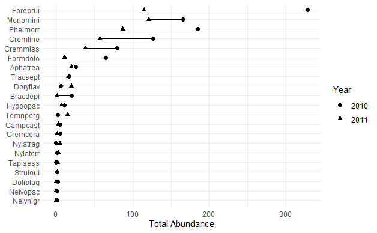

```r
ants_summarized %>%
  ggplot(aes(x = reorder(species, `total abundance`),
                         y = `total abundance`), group = species) +
  geom_line() +
  geom_point(mapping = aes(shape = year), size = 2) +
  coord_flip() +
  labs(x = NULL, y = 'Total Abundance', shape = 'Year') +
  theme_minimal()
```

### Part 3 :Featuring Phlox Flowers

#### Import and wrangle the first data set

```r
flower_import <- read_csv(here('data', 'flower_size.csv'))
flower_import
```

| Herbarium accession sheet | Species | Flower number | Corolla length (cm) | Corolla width throat (cm) | Mean corolla length (cm) | Standard Deviation corolla length (cm) | Mean corolla width (cm) | Standard deviation corolla width (cm) | Length width ratio |
| --- | --- | --- | --- | --- | --- | --- | --- | --- | --- |
| Acanthogilia gloriosa KANU00172801 | Acanthogilia gloriosa | 1 | 3.552 | 0.393 | NA | NA | NA | NA | NA |
| Acanthogilia gloriosa KANU00172802 | Acanthogilia gloriosa | 1 | 3.696 | 0.455 | NA | NA | NA | NA | NA |
| Acanthogilia gloriosa KANU00172802 | Acanthogilia gloriosa | 2 | 2.660 | 0.370 | NA | NA | NA | NA | NA |
| Acanthogilia gloriosa KANU00172802 | Acanthogilia gloriosa | 3 | 2.874 | 0.375 | NA | NA | NA | NA | NA |
| NA | Acanthogilia gloriosa | NA | NA | NA | 3.1955000 | 0.50587054 | 0.39825000 | 0.039101364 | 8.023854 |
| Aliciella caespitosa KSC0126229 | Aliciella caespitosa | 1 | 1.652 | 0.241 | NA | NA | NA | NA | NA |
| Aliciella caespitosa KSC0126229 | Aliciella caespitosa | 2 | 1.664 | 0.148 | NA | NA | NA | NA | NA |
| Aliciella caespitosa KSC0126229 | Aliciella caespitosa | 3 | 1.885 | 0.201 | NA | NA | NA | NA | NA |
| NA | Aliciella caespitosa | NA | NA | NA | 1.7336667 | 0.13119578 | 0.19666667 | 0.046651188 | 8.815254 |
| Aliciella formosa MO275448 | Aliciella formosa | 1 | 1.970 | 0.201 | NA | NA | NA | NA | NA |

[output cut: 990 more lines]

```r
flower_wrangled <- flower_import %>%
  filter(!is.na('Flower number')) %>%
  select(species = 'Species', cor_length = `Corolla length (cm)`, throat_width = `Corolla width throat (cm)`) %>%
  separate(species, into = c('genus', 'species'), extra = 'drop') %>%
  group_by(genus, species) %>%
  summarise(mean_length = mean(cor_length, na.rm = TRUE),
            mean_width = mean(throat_width, na.rm = TRUE),
            max_length = max(cor_length),
            max_width = max(throat_width)
            ,.groups = 'drop')
flower_wrangled
```

| genus | species | mean_length | mean_width | max_length | max_width |
| --- | --- | --- | --- | --- | --- |
| Acanthogilia | gloriosa | 3.1955000 | 0.39825000 | NA | NA |
| Aliciella | caespitosa | 1.7336667 | 0.19666667 | NA | NA |
| Aliciella | formosa | 2.1168889 | 0.29722222 | NA | NA |
| Aliciella | haydenii | 1.5810000 | 0.20946667 | NA | NA |
| Aliciella | heterostyla | 1.1081667 | 0.14466667 | NA | NA |
| Aliciella | hutchinsifolia | 0.8175000 | 0.15833333 | NA | NA |
| Aliciella | latifolia | 0.5560000 | 0.09633333 | NA | NA |
| Aliciella | leptomeria | 0.5180000 | 0.09633333 | NA | NA |
| Aliciella | lottiae | 0.6360000 | 0.12833333 | NA | NA |
| Aliciella | mcvickerae | 0.6646667 | 0.14133333 | NA | NA |

[output cut: 325 more lines]

#### Import and wrangle the second data set

```r
pollinators_raw <- read_csv(here('data', 'flower_pollinators.csv'))
pollinators <- pollinators_raw %>%
  select(-(Color | starts_with("Source"))) %>%
  drop_na("Pollinator") %>%
  separate(Species, into = c("genus", "species"), extra = 'drop') %>%
  separate(Pollinator, into = "Syndrome", extra = 'drop')
pollinators
```

| genus | species | Syndrome |
| --- | --- | --- |
| Acanthogilia | gloriosa | hummingbird |
| Aliciella | caespitosa | hummingbird |
| Aliciella | hutchinsifolia | autogamous |
| Aliciella | leptomeria | autogamous |
| Aliciella | micromeria | autogamous |
| Aliciella | pinnatifida | bee |
| Aliciella | subnuda | hummingbird |
| Allophyllum | divaricatum | beefly |
| Allophyllum | gilioides | autogamous |
| Allophyllum | glutinosum | bee |

[output cut: 182 more lines]

#### Join the Datasets

Use inner_join to join the smaller data set to the larger set. As long as your column names for genus and species are identical in both tibbles (e.g., genus and species), the join function will automatically match both columns when merging the data.

```r
joined_data <- flower_wrangled %>%
  inner_join(pollinators)
```

#### Plotting

Make a scatterplot to show the relationship between mean_length (x-axis) and mean_width (y-axis). Color the points by Syndrome.

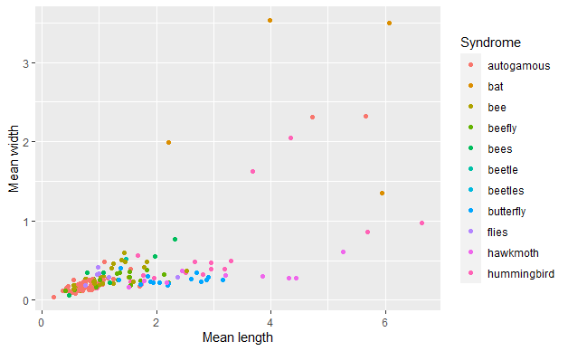

```r
joined_data %>%
  ggplot() +
  geom_point(mapping = aes(x = mean_length, y = mean_width, color = Syndrome)) +
  labs(x = "Mean length", y = "Mean width")
```

Use mutate with str_replace() and regex patterns to replace all occurences of “beetle” with “beetles,” and “bee” with “bees”. Be careful. If you don’t do this right, then you could end up with “beetless”. Make use of the $ match character.

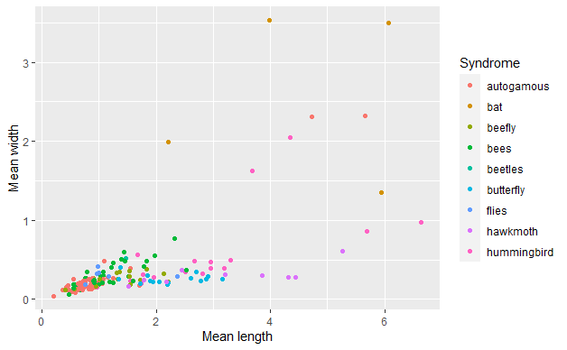

```r
joined_data %>%
  mutate(Syndrome = str_replace(Syndrome, "(^be.*e$)", "\\1s")) %>%
  ggplot() +
  geom_point(mapping = aes(x = mean_length, y = mean_width, color = Syndrome)) +
  labs(x = "Mean length", y = "Mean width")
```

Once again, use mutate() with str_replace and a regex pattern to replace all instances of “beetles” or “flies” with “other insects”.

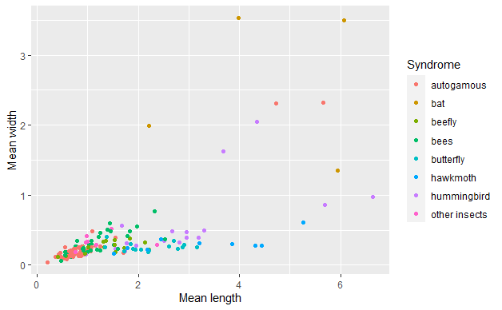

```r
joined_data %>%
  mutate(Syndrome = str_replace(Syndrome, "(^be.*e$)", "\\1s")) %>%
  mutate(Syndrome = str_replace(Syndrome, '(beetles|flies)', 'other insects')) %>%
  ggplot() +
  geom_point(mapping = aes(x = mean_length, y = mean_width, color = Syndrome)) +
  labs(x = "Mean length", y = "Mean width")
```

Use mutate and case_when to create a new column called syndrome_group and to change autogamous to Autogamous (upper case A), bat to Mammal, hummingbird to Bird, and everything else to Insect. Creating a new column would allow you to access the individual syndromes for future plots, when necessary.

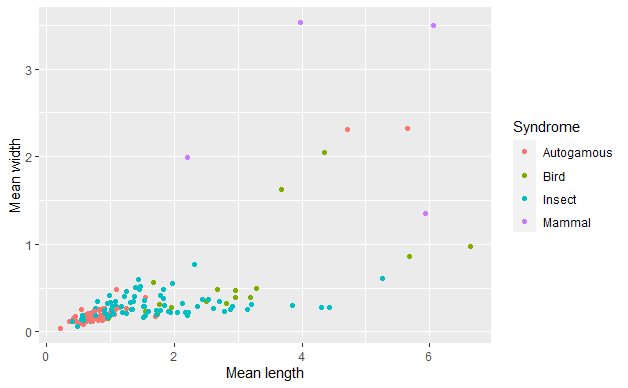

#### Highlighting groups with gghighlight

Change the above plot so that it highlights both the mammal and bird syndrome groups.

```
Tried to calculate with group_by(), but the calculation failed.
Falling back to ungrouped filter operation...
```

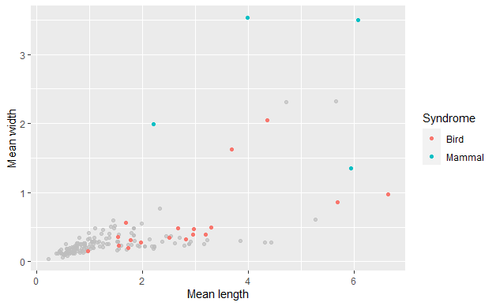

```r
mutated_data %>%
  ggplot(aes(mean_length, mean_width, color = syndrome_group)) +
  geom_point() +
  labs(x = "Mean length", y = "Mean width", color = "Syndrome") +
  gghighlight(syndrome_group == "Mammal" | syndrome_group == "Bird",
              use_direct_label = FALSE)
```

#### Other improvements: colors and themes

### Part 4: Customize your plots

#### Plot 1

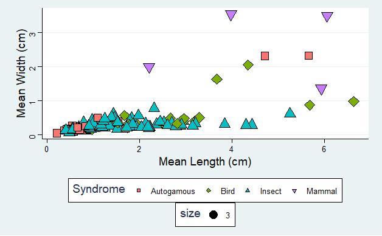

#### Plot 2

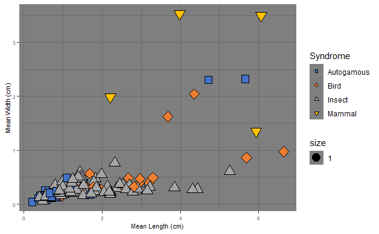

### Plot 3

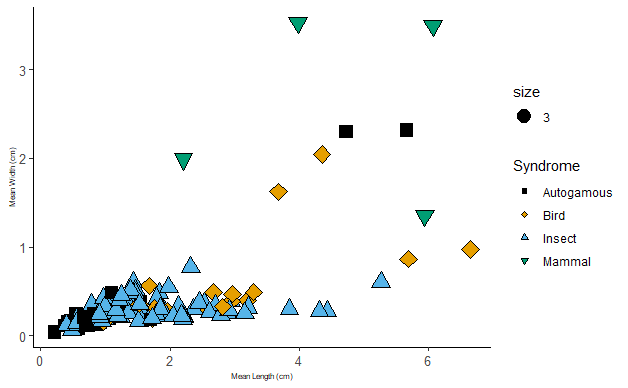

#### Plot 4

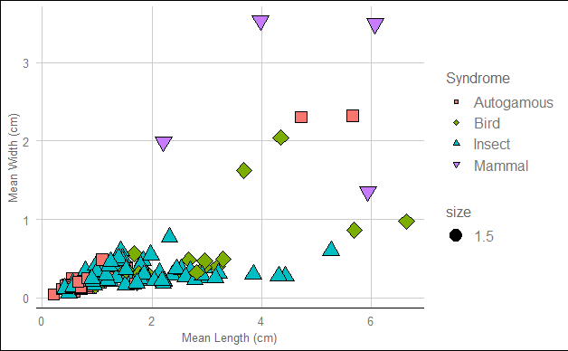